# Exploration of Tooth Growth Dataset

F16Falcon

March 2, 2016

### Synopsis

This document describes a statisical summary performed on the ToothGrowth dataset. The study performed by E.W. Crampton analyzes the impact of Vitamin C on the growth of the incisors of guinea pigs. The source of the data found in the ToothGrowth dataset is C.I Bliss (1952) *The Statistics of Bioassay.* Academic Press. A copy of the original study is avaiable in *The Journal OF Nutrition* at http://jn.nutrition.org/content/33/5/491.full.pdf.

The study examines the response in the length of odontoblasts (cells responsible for tooth growth) in 60 guinea pigs, each receiving one of three dose levels of Vitamin C (0.5, 1.0, and 2.0 mg) with one of two delivery methods (orange juice or an aqueous solution of ascorbic acid). The summary that follows examines two hypotheses:

1. The dataset supports a hypothesis that the administration of Vitamin C (ascorbic acid) promotes tooth growth in guinea pigs. More specifically, the dataset supports a hypothesis that there is a positive correlation between the dosage administered and tooth growth, measured by a greater mean tooth length.
2. The dataset supports a hpothesis that the delivery of Vitamin C delivered by orange juice promotes greater tooth growth than aqueous solution, measured by a greater mean tooth length.

### Data

The information in the ToothGrowth dataset is a data frame with 60 observations (60 guinea pigs), and three variables: (1) len, which is the odontoblast length in microns; (2) supp, which is the supplement type (orange juice or aqueous solution of ascorbic acid); and (3) dose, in milligrams (0.5, 1.0, and 2.0).

### Analysis

The analysis begins by taking an exploratory look at the data. The table that follows shows the average tooth length (microns) by supplement and dose (milligrams).

```
## Source: local data frame [6 x 3]
## Groups: supp [?]
##
##   Supplement  Dose Mean Length
##       (fctr) (dbl)       (dbl)
## 1         OJ   0.5       13.23
## 2         OJ   1.0       22.70
## 3         OJ   2.0       26.06
## 4         VC   0.5        7.98
## 5         VC   1.0       16.77
## 6         VC   2.0       26.14
```

A cursory look at the distribution of tooth growth by supplement shows that the median tooth growth is higher for the guinea pigs that received Vitamin C from orange juice, versus those who receive Vitamin C via an aqueous solution. The boxplot also shows that the dispersion of tooth growth is greater for the guinea pigs who received the aqueous solution versus orange juice. We will examine whether this effect is statistically significant.

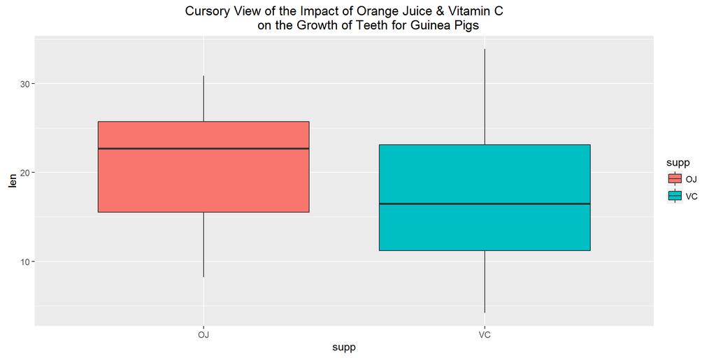

The results of the boxplot are supported by the following line charts that shows the relationship between length, dose, and supplement. It would appears from these charts that at lower dosages, Vitamin C delivered via orange juice promotes tooth growth more effectively than Vitamin C delivered via aqueous solution .

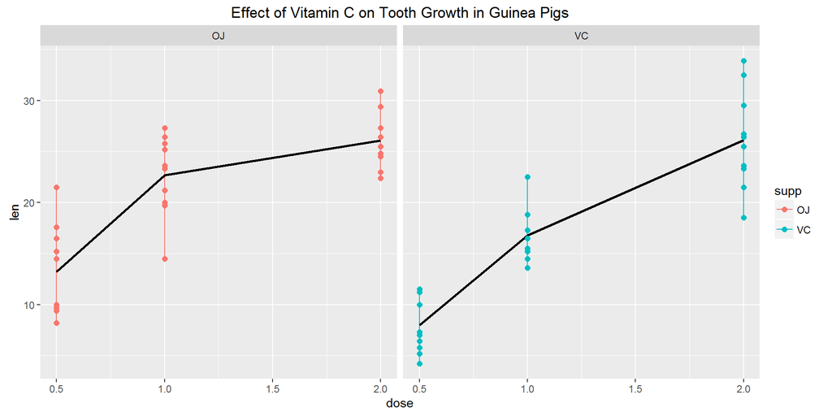

To test the first hypothesis, that the dataset supports a hypothesis that the administration of Vitamin C promotes tooth growth, I computed six test statistics measuring the difference in the mean tooth length by dose and supplement. These statistics compare the difference in mean tooth length for pairings of doses, by supplement. The test statistics labeled Tstat(x), where x=1,…,6, represent the following comparison:

- Tstat1: computes the mean length from aqueous solution at 2.0 mg - mean length from aqueous solution at 0.5 mg
- Tstat2: computes the mean length from aqueous solution at 1.0 mg - mean length from aqueous solution at 0.5 mg
- Tstat3: computes the mean length from aqueous solution at 2.0 mg - mean length from aqueous solution at 1.0 mg
- Tstat4: computes the mean length from orange juice at 2.0 mg - mean length from orange juice at 0.5 mg
- Tstat5: computes the mean length from orange juice at 1.0 mg - mean length from orange juice at 0.5 mg
- Tstat6: computes the mean length from orange juice at 2.0 mg - mean length from orange juice at 1.0 mg

I computed confidence intervals and p-values at the 95th confidence level for each statistic, which are shown in the following table:

```
##        Lower Bound Upper Bound      P-value
## Tstat1     14.4185     21.9015 4.681577e-08
## Tstat2      6.3143     11.2657 6.811018e-07
## Tstat3      5.6857     13.0543 9.155603e-05
## Tstat4      9.3248     16.3352 1.323784e-06
## Tstat5      5.5244     13.4156 8.784919e-05
## Tstat6      0.1886      6.5314 3.919514e-02
```

For each test statistic the Null hypothesis (i.e., that the mean difference in tooth length is zero) is rejected, since zero is not present in any of the confidence intervals and the p_values are smaller than the 5% test level. Based on these statistics, I conclude that Vitamin C administered by either method, orange juice or aqueous solution promotes tooth growth, given the data in the study. In addition, the amount of growth is positively correlated to the amount of Vitamin C delivered.

To address the second hypothesis, *that the dataset supports a hypothesis that the delivery method, orange juice or an aqueous solution of ascorbic acid, promotes different level of tooth growth, measured by a greater mean tooth length*, I computed three test statistics mesuring the mean difference in tooth length given the same dose level, but different delivery method. The test statistics labeled Tstat(x), where x=7,…9, represent the following comparison:

- Tstat7: computes the mean length from orange juice at 0.5 mg - mean length from aqueous solution at 0.5 mg
- Tstat8: computes the mean length from orange juice at 1.0 mg - mean length from aqueous solution at 1.0 mg
- Tstat9: computes the mean length from orange juice at 2.0 mg - mean length from aqueous solution at 2.0 mg

Again, I computed confidence intervals and p-values at the 95th confidence level for each statistic, which are shown in the following table:

```
##        Lower Bound Upper Bound     P-value
## Tstat7      1.7191      8.7809 0.006358607
## Tstat8      2.8021      9.0579 0.001038376
## Tstat9     -3.7981      3.6381 0.963851589
```

The results show that we can reject the Null hypotheses (i.e., that the mean difference in tooth length is zero) for dose level 0.5 mg and 1.0 mg. This supports the alternative hypotheses that tooth growth is promoted when delivered by orange juice relative to aqueous solution in doses of 0.5 mg and 1.0 mg. However, we cannot reject the Null hypothesis at the dose level of 2.0 mg.

### Conclusion

I tested two hypotheses based on the data in the ToothGrowth dataset. The first hypothesis was that tooth growth was promoted by the administration of Vitamin C. I examined this hypothesis by testing the proposition of zero mean tooth growth against positive mean tooth growth. In all, cases the test statistic allowed for the rejection of the Null hypothesis of zero mean growth, and therefore leads to the conclusion that tooth growth is promoted by the administration of Vitamin C, regardless of the mode of delivery.

The second hypothesis postulated that Vitamin C delivered via orange juice promoted greater tooth growth than Vitamin C delivered via an aqueous solution. The test statistics for this hypothesis compared the mean growth of the two delivery methods at the same dose level. We found that at 0.5 mg, and 1.0 mg, we were able to reject the Null hypothesis that the mean difference in tooth growth was zero. Therefore, the alternative hypothesis would indicate that at 0.5 mg and 1.0 mg, Vitamin C delivered via orange juice promotes greater tooth growth than Vitamin C delivered via an aqueous solution. However, we could not reject the Null hypothesis at the 2.0 mg dose level. So it is not statistically possible to say that Vitamin C delivered via orange juice promotes greater tooth growth than Vitamin C delivered via an aqueous solution.

### Appendix

I used simulation to bootstrap distributions to test the two hypotheses. For the first hypothesis, I created distributions to examine Tsat1 (compares the mean length from aqueous solution at 2.0 mg - mean length from aqueous solution at 0.5 mg) and Tstat4 (compares the mean length from orange juice at 2.0 mg - mean length from orange juice at 0.5 mg).

I then used simulation to test the hpothesis that Vitamin C delievered via orange juice at 2.0 mg promoted greater tooth growth than Vitamin C delivered via aqueous solution at 2.0 mg.

In the simulations that follow the black vertical line is drawn at the observed test statistic. The fact that all of the outcomes in the histogram fall to the left of the line for the first two charts indicate that the p_value is below the selected 5% error rate, and supports rejection of the Null hypothesis (in both cases the P-Value was zero. In the third chart the vertical line is much closer to the center of the distribution and corresponds to a p-value of 0.5, which is above the 5% error rate. This supports the fact that the Null hypothesis cannot be rejected.

**Note**. perm represents the permutations that resulted from the simulation.

```
## [1] 0
```

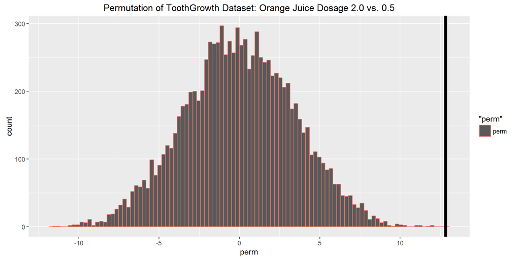

```
## [1] 0
```

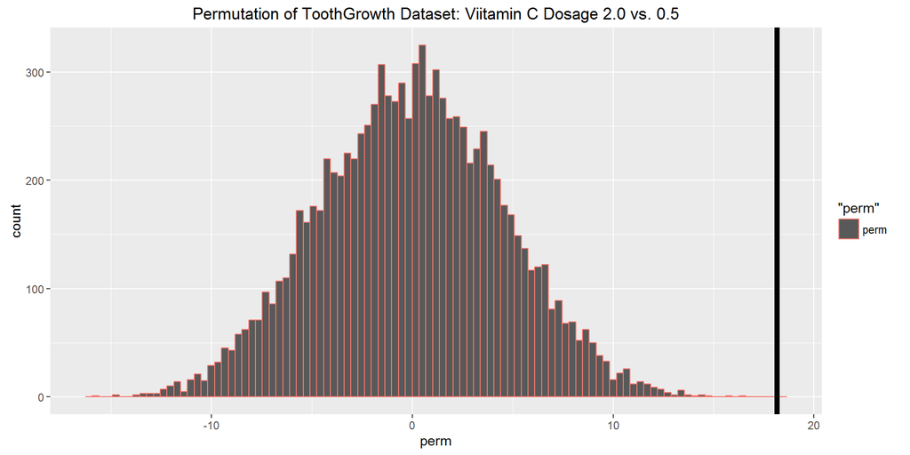

```
## [1] 0.5166
```

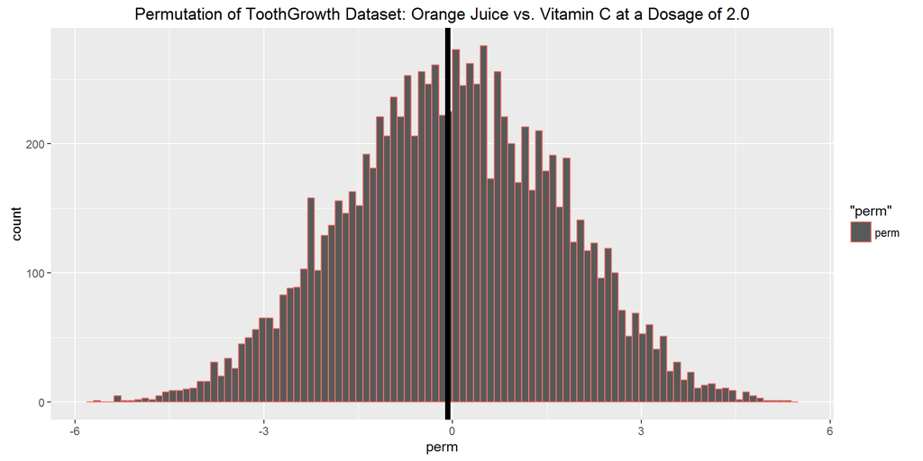